# Part 3 - Testing our best model

## Deciding if our model is good enough to be deployed

## 🚨 This is the continuation of the previous notebook. If this is the first file you are opening during correctiong, considering reviewing the readme file to understand how this project is structured.

In the previous files:

- ✅ we have prepared our datasets: we have split our data into 4 different datasets for train/hp_tuning/val/test
- ✅ we have explored our data to get a general understanding of what it looks like
- ✅ we have found ways to engineer new features that helped our predictive power.
- ✅ we have used tools from Inferential Statistics and Information Theory to help us understand which features are more likely to contribute to our models
- ✅ we have automated our data cleaning processes and stored fresh/cleaned data on disk to save us valuable time
- ✅ we have created a few predictive models, and tuned them properly.

In this file:

- We will check if our best performing model is ready to go live.
- We will retrieve our original success criteria and we will compare it with our model's performance on unseen data.
- We will create a simple Flask application that can make predictions
- We will deploy our application to Google Cloud

This notebook begins with the same boilerplate as the other ones (imports, basic feature toggles, etc...)

## Imports and initial setup

```python
import ipywidgets as widgets
from IPython.display import display, Markdown, Image, clear_output, HTML, IFrame, JSON
import matplotlib.pyplot as plt
from matplotlib.patches import Rectangle
from mpl_toolkits.mplot3d import Axes3D
import itertools

import numpy as np
import pandas as pd
import polars as pl
import sqlite3
import seaborn as sns
from scipy import stats
from scipy.stats import chi2_contingency
import missingno as msno
import klib
import warnings

import statsmodels.api as sm

from random import random, seed
import sqlite3 as lite
import logging
import warnings
import ydata_profiling
import iplantuml
import xml.dom.minidom

from sklearn.feature_selection import SelectKBest, f_regression
from sklearn.metrics import (
    ConfusionMatrixDisplay,
    precision_recall_curve,
    accuracy_score,
    recall_score,
    precision_score,
    make_scorer,
    confusion_matrix,
    f1_score,
    PrecisionRecallDisplay,
    roc_auc_score,
)

from autofeatselect import CorrelationCalculator, FeatureSelector, AutoFeatureSelect

from sklearn.preprocessing import RobustScaler, FunctionTransformer
from sklearn.impute import SimpleImputer
from sklearn.decomposition import PCA
from sklearn.linear_model import LinearRegression, LogisticRegression
from sklearn.model_selection import GridSearchCV
from sklearn.tree import plot_tree
from sklearn.metrics import make_scorer, confusion_matrix, PrecisionRecallDisplay
from sklearn.pipeline import Pipeline
from sklearn.impute import KNNImputer
from sklearn.pipeline import make_pipeline
from sklearn.compose import ColumnTransformer
from sklearn.base import BaseEstimator, TransformerMixin
from sklearn.base import clone as clone_pipeline
from sklearn.experimental import enable_iterative_imputer
from sklearn.impute import IterativeImputer
from sklearn.neighbors import NearestNeighbors

from sklearn.ensemble import RandomForestClassifier, ExtraTreesClassifier
from sklearn.linear_model import LogisticRegression
from xgboost import XGBClassifier
from sklearn.model_selection import GridSearchCV
from sklearn.svm import SVC
import shap
import yellowbrick

from imblearn.under_sampling import RandomUnderSampler
import joblib
import pickle

import os
from os import path

from utils import *
from utils import __

from autofeat import AutoFeatRegressor as AFR
from sklearn.model_selection import train_test_split as sklearn_train_test_split
from sklearn.exceptions import DataConversionWarning
import sweetviz as sv

import featuretools as ft
import woodwork as ww
import json
import subprocess

import category_encoders as ce

warnings.filterwarnings("ignore", category=DeprecationWarning)
warnings.filterwarnings("ignore", category=FutureWarning)
seed(100)
pd.options.display.max_rows = 100
pd.options.display.max_colwidth = 50
util.check("done")
```

```
✅
```

```python
%reload_ext credit_clean
%reload_ext credit_utils

import credit_clean
import credit_utils
```

Let's use `black` to auto-format all our cells so they adhere to PEP8

```python
import lab_black

%reload_ext lab_black
util.patch_nb_black()
# fmt: off
# fmt: on
```

```python
from sklearn import set_config

set_config(transform_output="pandas")
```

```python
sns.set_theme(context="notebook", style="whitegrid")

moonstone = "#62b6cb"
moonstone_rgb = handy_utils.hex_to_rgb(moonstone)
moonstone_rgb_n = np.array(moonstone_rgb) / 255
```

```python
logger = util.configure_logging(jupyterlab_level=logging.WARN, file_level=logging.DEBUG)


# import warnings
# warnings.filterwarnings('error', category=pd.errors.DtypeWarning)
```

```python
def ding(title="Ding!", message="Task completed"):
    """
    this method only works on linux
    """
    for i in range(2):
        !notify-send '{title}' '{message}'
```

## Feature Toggles

Let's also create a simple feature toggle that we can use to skip expensive operations during notebook work (to save myself some time!)

Set it to true if you want to run absolutely everything. Set to false to skip optional steps/exploratory work.

```python
def run_entire_notebook(filename: str = None):
    run_all = False
    if not run_all:
        print("skipping optional operation")
        fullpath = f"cached/printouts/{filename}.txt"
        if filename is not None and os.path.exists(fullpath):
            print("==== 🗃️ printing cached output ====")
            with open(fullpath) as f:
                print(f.read())
    return run_all
```

We will also create a small settings file to store all of the tweaks/configs we might need during production (TRAIN/FIT/DEPLOYED MODEL) so we can guarantee that we rely on this instead of having to remember/risking misconfiguring

# Checking our model's performance

We are ready to finally test our best performing model.

```python
def xy_clean_save(X: pd.DataFrame, y: pd.Series, name: str):
    X.to_parquet(f"dataset/clean/{name}_X.parquet", compression="gzip")
    pd.DataFrame(y).to_parquet(f"dataset/clean/{name}_y.parquet", compression="gzip")


def xy_read(name: str) -> tuple[pd.DataFrame, pd.Series]:
    X = pd.read_parquet(f"dataset/clean/{name}_X.parquet")
    y = pd.read_parquet(f"dataset/clean/{name}_y.parquet")["target"]
    return X, y
```

```python
X_training, y_training = xy_read("training")
X_training, y_training = eda_utils.balance_xy(X_training, y_training)
```

```python
X_test, y_test = xy_read("test")
```

```python
y_training.value_counts()
```

```
1    12280
0    12280
Name: target, dtype: int64
```

```python
y_test.value_counts()
```

```
0    21633
1     1871
Name: target, dtype: int64
```

```python
best_model = optuna_utils.get_best_model("model_xgbclassifier")
```

```python
best_model.fit(X_training, y_training)
```

```
XGBClassifier(base_score=0.5, booster='gbtree', colsample_bylevel=1,
              colsample_bynode=1, colsample_bytree=0.3017066331755987,
              gamma=0.010464585053241961, gpu_id=-1, importance_type='gain',
              interaction_constraints='', learning_rate=0.010998589853339952,
              max_delta_step=0, max_depth=4, min_child_weight=9, missing=nan,
              monotone_constraints='()', n_estimators=800, n_jobs=16,
              num_parallel_tree=1, random_state=42,
              reg_alpha=0.0002096718374236909, reg_lambda=1, scale_pos_weight=1,
              subsample=0.6561983312530707, tree_method='exact',
              validate_parameters=1, verbosity=None)
```

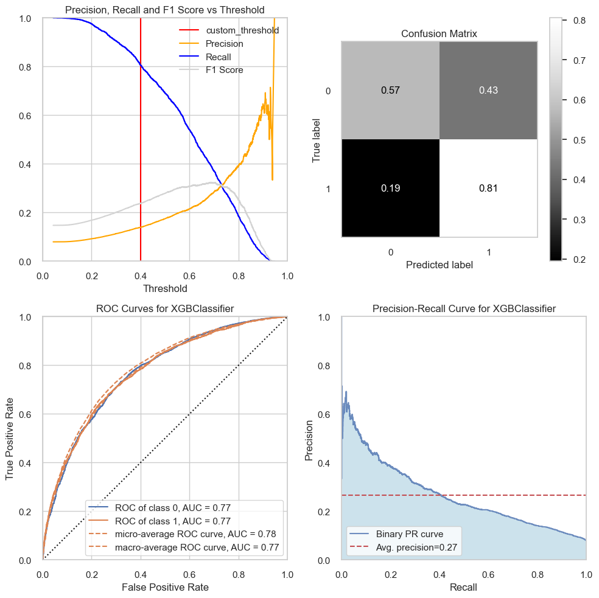

```python
proba_threshold = 0.40
fig, ax = plt.subplots(2, 2, figsize=(10, 10))

cax_thr = ax[0, 0]
cax_conf = ax[0, 1]
cax_roc = ax[1, 0]
cax_pr = ax[1, 1]

chart_utils.plot_precision_recall_f1_scores(
    fitted_probab_model=best_model,
    X_test=X_test,
    y_true=y_test,
    threshold=proba_threshold,
    ax=cax_thr,
)

y_pred_proba = best_model.predict_proba(X_test)
y_pred = y_pred_proba[:, 1] > proba_threshold

ConfusionMatrixDisplay.from_predictions(
    y_test,
    y_pred,
    labels=[0, 1],
    display_labels=[0, 1],
    normalize="true",
    ax=cax_conf,
    cmap="Greys_r",
)
cax_conf.grid(False)
cax_conf.set_title(f"Confusion Matrix")

cm = yellowbrick.classifier.ROCAUC(best_model, is_fitted=True, ax=cax_roc)
cm.fit(X_training, y_training)
cm.score(X_test, y_test)
cm.finalize()

cm = yellowbrick.classifier.PrecisionRecallCurve(best_model, is_fitted=True, ax=cax_pr)
cm.fit(X_training, y_training)
cm.score(X_test, y_test)
cm.finalize()

plt.tight_layout()
```

```python
accuracy_score(y_test, y_pred)
```

```
0.5882828454731109
```

Summary:

|  | Hyperparameter Tuning (80%/20% split) | Training/Test (full datasets) | Success Threshold | GO LIVE/NOGO LIVE Decision |
| --- | --- | --- | --- | --- |
| TPR | 0.83 | 0.81 | > 80% | ✅ Above threshold |
| TNR | 0.53 | 0.57 | > 50% | ✅ Above threshold |
| Accuracy | 0.68 | 0.59 | > 80% | ❌ |
| ROC AUC | 0.77 | 0.77 | No target set | ✅ Generalizes well |

There are a few things we like:

- ✅ Our model is able to generalize well on unseen data
- ✅ It performs with similar scores as previous rounds (which were using other splits and less data)
- ✅✅✅❌ Almost all of the threshold and criteria we set at the beginning of the project are met.
  - It is likely that our goal for accuracy was too optimistic. In general, at this point we would go and check with the business team so an informed decision can be made.
  - If they require ALL of the criteria to go live, we could do a few more iterations of model improvement (from the beginning: create new features that seem promising, etc..)

As we disclosed initially, since this is a learning project and we are required to deploy something to google cloud platform, we will deploy it, even if 1 of the targets is not met.

# Model deployment

This model requires data from a variety of places:

- current application data
- historical data (credit/balance/point of sale/etc...)

Some of these pieces of data are only available "right now" when the customer requests the information for a credit/load, but the historical ones are available well before that.

## Options Available

### Option 1 - Create a Stateless service

**Option One** would be to create **a stateless service**, and then we require the requestor/HTTP client to provides us all of the data that we will need to make predictions.

Not great:

- cumbersome to implement
  - high dependency on pipelines and transformations. Any time changes in terms of preprocessing, the server must be changed or trigger a reload of cleaning pipelines.
- Heavy payloads
  - client must provide all of the data (some of the data might already be available to us from more trustworthy sources)
- Brittle contracts/fields
  - changes to fields/fieldnames/types/etc...
- Potentially less secure
  - potentially vulnerable to data poisoning/injection from malicious actors.

### Option 2 - Query a Feature Store

**Option Two** is to use a different paradigm: **a Feature Store** to store customer-historical data and then the requestor only needs to provide data that we don't have yet (the last bit of data that they submit when they submit an application).

Benefits:

- HTTP Client/Requestor only needs to provide the last bits of data we do not yet have (for example):
  - amt_income_total
  - amt_credit
  - amt_annuity
  - amt_goods_price
  - days_birth
  - days_employed

(we're imagining that the historical data is collected weekly/daily but that we don't have some details related to the application)

## Creating our Feature Store

For our feature store, we could have a precomputed set of features for our clients and we retrieve the relevant info for our client when a new request comes in.

Data that we expect in client requests:

- amt_income_total
- amt_credit
- amt_annuity
- amt_goods_price
- days_birth
- days_employed
- credit_annuity_ratio (not required to be provided, we will calculate it ourselves)

Data we will retrieve from the Feature Store:

- all the other data (things that do not change frequently and that we can precompute before the client even comes to us)

This list could be debated and adjusted as needed, this is just a simplified example.

We have carefully selected these feature so that the process is a bit more complex than the most trivial code example, but without making it unnecessarily convoluted.

### Loan Application Features

These are features that we won't know until the day they come to apply for a loan, so we cannot keep them in our feature store (it's just an example!)

```python
loan_features = [
    "amt_income_total",
    "amt_credit",
    "amt_annuity",
    "amt_goods_price",
    "days_birth",
    "days_employed",
    "credit_annuity_ratio",
]
```

### Feature Store for historical trends & aggregates

These are the features we can aggregate and update regularly, most of these come from 3rd party agencies or other divisions of the bank. These are unlikely to change regularly and can be recomputed once a day/week/month as needed to simplify prediction.

```python
feature_store = X_test
feature_store = feature_store.drop(columns=loan_features)
feature_store.to_parquet(
    "../app/feature_store/feature_store_test.parquet", compression="gzip"
)
feature_store
```

| sk_id_curr | name_contract_type_Revolving loans | code_gender_M | flag_own_car_N | flag_own_realty_N | cnt_children | name_type_suite_Family | name_type_suite_Spouse, partner | name_type_suite_Children | name_type_suite_Other_B | name_type_suite_Group of people | ... | MAX(installments_payments.amt_instalment) | MAX(installments_payments.days_entry_payment) | MAX(installments_payments.days_instalment) | MAX(installments_payments.num_instalment_number) | MEAN(installments_payments.num_instalment_number) | MEAN(installments_payments.num_instalment_version) | MIN(installments_payments.amt_instalment) | MIN(installments_payments.amt_payment) | SUM(installments_payments.amt_payment) | ext_source_annuity_avg |
| --- | --- | --- | --- | --- | --- | --- | --- | --- | --- | --- | --- | --- | --- | --- | --- | --- | --- | --- | --- | --- | --- |
| 357651 | 0.0 | 1.0 | -1.0 | 0.0 | 0.0 | 0.0 | 0.0 | 0.0 | 0.0 | 0.0 | ... | -0.229845 | -2.067751 | -2.089918 | -0.071429 | -0.212445 | 0.720000 | -0.256189 | -0.321742 | -0.324972 | 0.130653 |
| 242701 | 0.0 | 0.0 | 0.0 | 0.0 | 0.0 | 0.0 | 0.0 | 0.0 | 0.0 | 0.0 | ... | -0.250297 | -0.902439 | -0.910082 | 0.000000 | 0.092368 | -0.180000 | -0.181845 | 0.183534 | -0.258129 | 0.020101 |
| 353606 | 0.0 | 1.0 | 0.0 | 0.0 | 1.0 | 0.0 | 0.0 | 0.0 | 0.0 | 0.0 | ... | -0.028452 | -5.720867 | -5.795640 | 6.357143 | 0.716508 | 0.784286 | -0.489005 | -0.321540 | -0.170606 | 0.025126 |
| 331169 | 0.0 | 0.0 | 0.0 | 0.0 | 2.0 | 0.0 | 0.0 | 0.0 | 0.0 | 0.0 | ... | -0.157656 | 0.157182 | 0.111717 | 1.142857 | 0.597111 | -4.099355 | -0.664948 | -0.303041 | 0.236668 | 0.175879 |
| 351821 | 0.0 | 0.0 | -1.0 | 1.0 | 0.0 | 0.0 | 0.0 | 0.0 | 0.0 | 0.0 | ... | -0.016484 | -0.181572 | -0.207084 | -0.428571 | -0.568060 | -0.180000 | 3.074104 | 3.462876 | 0.321849 | 0.060302 |
| ... | ... | ... | ... | ... | ... | ... | ... | ... | ... | ... | ... | ... | ... | ... | ... | ... | ... | ... | ... | ... | ... |
| 149098 | 0.0 | 0.0 | 0.0 | 0.0 | 0.0 | 0.0 | 0.0 | 0.0 | 0.0 | 0.0 | ... | -0.243648 | -1.769648 | -1.803815 | -0.428571 | -0.517258 | -0.180000 | 0.380810 | 0.750231 | -0.368026 | 0.095477 |
| 190746 | 0.0 | 0.0 | -1.0 | 0.0 | 0.0 | 0.0 | 0.0 | 0.0 | 0.0 | 0.0 | ... | -0.082451 | -0.300813 | -0.356948 | 0.000000 | 0.295576 | -0.180000 | 3.249781 | -0.241103 | 0.038111 | 0.180905 |
| 364486 | 0.0 | 0.0 | 0.0 | 0.0 | 0.0 | 0.0 | 0.0 | 0.0 | 0.0 | 0.0 | ... | -0.201426 | 0.113821 | 0.106267 | 0.857143 | 0.640529 | -0.180000 | -0.198342 | 0.166918 | 0.494866 | 0.045226 |
| 230358 | 0.0 | 0.0 | -1.0 | 1.0 | 1.0 | 1.0 | 0.0 | 0.0 | 0.0 | 0.0 | ... | 9.751068 | 0.151762 | 0.106267 | 6.142857 | 5.967566 | -5.896216 | -0.682147 | -0.321729 | 5.463204 | 0.025126 |
| 277236 | 0.0 | 0.0 | 0.0 | 1.0 | 0.0 | 0.0 | 0.0 | 0.0 | 0.0 | 0.0 | ... | -0.260285 | -1.761518 | -1.833787 | 0.000000 | 0.182682 | -0.180000 | 0.075656 | -0.321612 | -0.339798 | 0.216080 |

23504 rows × 158 columns

## Storing our Model

This is the model we have tuned and trained on all the training data

```python
xgboost_expected = best_model.get_booster().get_score(importance_type="weight").keys()
xgboost_expected
```

[output not shown]

```python
joblib.dump(best_model, filename="../app/model/best_model.joblib")
```

```
['../app/model/best_model.joblib']
```

## Storing some Data Preprocessors

This is an example of how we could import pre-processing steps from our data cleaning notebook for reuse in our application.

The process is fairly similar whether we need 1 step or 4 enormous pipelines. In this case, we're using this as a stand-in example for "all preprocessing steps"

```python
p_clean = Pipeline(steps=[("add_credit_annuity_ratio", credit_clean.AddCreditAnnuity)])
joblib.dump(p_clean, filename="../app/preprocessors/cleaning_pipeline.joblib")
```

```
['../app/preprocessors/cleaning_pipeline.joblib']
```

```python
X_test.reset_index()[loan_features + ["sk_id_curr"]].head(10).to_json(
    "../app/sample_body/10_sample_customers.json",
    orient="index",
    indent=2,
)
```

# Application

## Developing a flask application to make predictions

These are just left here as a quick showcase, the entire codebase is available in the root of this repository under the `/app` directory

[figure not shown]

## Checking the application

[figure not shown]

## Interactive playground to use the application

```python
payload = {
    "sk_id_curr": 353606,
    "amt_income_total": 2.0,
    "amt_credit": 1.1838703775,
    "amt_annuity": 2.2133067531,
    "amt_goods_price": 1.44,
    "days_birth": -0.5026603192,
    "days_employed": 0.302745098,
    "credit_annuity_ratio": -0.2134566166,
}
```

```python
import http.client
import json

conn = http.client.HTTPConnection("localhost:5000")
json_payload = json.dumps(payload)
headers = {"Content-Type": "application/json"}
conn.request("POST", "/predictions/loan", json_payload, headers)
res = conn.getresponse()
data = res.read()
response = data.decode("utf-8")
```

```python
JSON(data=response, expanded=True)
```

## Deployment of the application to google cloud

### Installing the docker image

We will deploy our app using the Google Cloud CLI, but we don't want to install it bare on our laptop.

This docker container comes ready and preconfigured and it will allow us to deploy without getting our laptop dirty and full of google libraries.

The steps can be found here: https://cloud.google.com/sdk/docs/downloads-docker

```python
google_cloud_project_name = "turnkey-timer-403114"
```

```
(flask) edu@flex:~$ docker pull gcr.io/google.com/cloudsdktool/google-cloud-cli:latest
latest: Pulling from google.com/cloudsdktool/google-cloud-cli
69b3efbf67c2: Pull complete
c08add558063: Pull complete
53ea745b59b5: Pull complete
9eb0b5bac949: Pull complete
8d8e414af8f5: Pull complete
c2e8be6ed4f3: Pull complete
d0cfca26fd34: Pull complete
Digest: sha256:6e1b51c012eef3ef9354cf542e08eefe09126d3bcf59d1c809e678df56560cf1
Status: Downloaded newer image for gcr.io/google.com/cloudsdktool/google-cloud-cli:latest
gcr.io/google.com/cloudsdktool/google-cloud-cli:latest

(flask) edu@flex:~$ docker run --rm gcr.io/google.com/cloudsdktool/google-cloud-cli:latest gcloud version
Google Cloud SDK 452.0.0
alpha 2023.10.23
app-engine-go 1.9.75
app-engine-java 2.0.21
app-engine-python 1.9.107
app-engine-python-extras 1.9.103
beta 2023.10.23
bigtable
bq 2.0.98
bundled-python3-unix 3.9.17
cbt 0.16.2
cloud-datastore-emulator 2.3.1
cloud-firestore-emulator 1.18.2
cloud-spanner-emulator 1.5.10
core 2023.10.23
gcloud-crc32c 1.0.0
gke-gcloud-auth-plugin 0.5.6
gsutil 5.26
kpt 1.0.0-beta.45
local-extract 1.5.9
pubsub-emulator 0.8.10

(flask) edu@flex:~$
```

We will create a custom alias to simplify the rest of the operations:

```
alias gcloud_docker='docker run --rm -ti --volumes-from gcloud-config gcr.io/google.com/cloudsdktool/cloud-sdk gcloud'
```

Next step is authorizing our CLI client to operate on our behalf:

[figure not shown]

The last important bit is to update the active project we will be working on, so things are deployed in the right place:

```
(flask) edu@flex:~$ gcloud_docker config set project turnkey-timer-403114
Updated property [core/project].

(flask) edu@flex:~$ gcloud_docker config list
[core]
account = edxxxxxxxxxxxxx@xxxmail.com
disable_usage_reporting = True
project = turnkey-timer-403114

Your active configuration is: [default]
(flask) edu@flex:~$
```

We're finally ready to deploy our application!

We will choose a region in 🇪🇺 Europe-West (likely Ireland 🇮🇪), to be covered by GDPR, given the extremely sensitive fake data that our application will be processing!

```
(flask) edu@flex:~/turing/projects/sprint12-home-default/app$ docker run --rm -ti --volumes-from gcloud-config -v /home/edu/turing/projects/sprint12-home-default/app:/app gcr.io/google.com/cloudsdktool/cloud-sdk gcloud app deploy /app/app.yaml
You are creating an app for project [turnkey-timer-403114].
WARNING: Creating an App Engine application for a project is irreversible and the region
cannot be changed. More information about regions is at
<https://cloud.google.com/appengine/docs/locations>.

Please choose the region where you want your App Engine application located:

 [1] asia-east1    (supports standard and flexible)
 [2] asia-east2    (supports standard and flexible and search_api)
 ... (omitted)
 [11] europe-west   (supports standard and flexible and search_api)
 ... (omitted)
 [23] us-west4      (supports standard and flexible and search_api)
 [24] cancel
Please enter your numeric choice:  11

Creating App Engine application in project [turnkey-timer-403114] and region [europe-west]....done.
Services to deploy:

descriptor:                  [/app/app.yaml]
source:                      [/app]
target project:              [turnkey-timer-403114]
target service:              [default]
target version:              [20231025t151454]
target url:                  [https://turnkey-timer-403114.ew.r.appspot.com]
target service account:      [turnkey-timer-403114@appspot.gserviceaccount.com]


Do you want to continue (Y/n)?  y

Beginning deployment of service [default]...
╔════════════════════════════════════════════════════════════╗
╠═ Uploading 30 files to Google Cloud Storage               ═╣
╚════════════════════════════════════════════════════════════╝
File upload done.
Updating service [default]...done.
Setting traffic split for service [default]...done.
Deployed service [default] to [https://turnkey-timer-403114.ew.r.appspot.com]

You can stream logs from the command line by running:
  $ gcloud app logs tail -s default

To view your application in the web browser run:
  $ gcloud app browse

(flask) edu@flex:~/turing/projects/sprint12-home-default/app$
```

## Testing the deployed application

Let's do the same thing we did earlier, but against the application deployed in Google Cloud

```python
payload = {
    "sk_id_curr": 353606,
    "amt_income_total": 200.0,
    "amt_credit": 1.1838703775,
    "amt_annuity": 2.2133067531,
    "amt_goods_price": 1.44,
    "days_birth": -0.5026603192,
    "days_employed": 0.302745098,
    "credit_annuity_ratio": -0.2134566166,
}
```

```python
import http.client
import json

conn = http.client.HTTPSConnection("turnkey-timer-403114.ew.r.appspot.com")
json_payload = json.dumps(payload)
headers = {"Content-Type": "application/json"}
conn.request("POST", "/predictions/loan", json_payload, headers)
res = conn.getresponse()
if res.status >= 300:
    raise ValueError(
        f"Something has gone terribly wrong with the request. HTTP STATUS CODE: {res.status} "
        "This could happen if you enter an invalid customer id and it cannot be found in the feature store."
    )
data = res.read()
response = data.decode("utf-8")
```

```python
JSON(data=response, expanded=True)
```

If we tail the logs from the remote server using:

`gcloud_docker app logs tail -s default`

[figure not shown]

The Google Cloud App Engine Management portal shows our incoming traffic and some basic stats:

[figure not shown]

# Next Steps

In this file, we have:

- Checked how our best model is performing.
- Retrieve our original success criteria and since most of the criteria was met, we have made an executive decision to go live.
- Created a simple Flask application that can make predictions.
- Deployed our application to Google Cloud

In the next notebook, we write down some conclusions and closing thoughts.

Don't forget to check one of the bonus challenges around exploring and comparing performance with a model generated using AutoML (TPOT)